Session 4: Making Causal Claims & Predicting the Future  
DSOM 5509: Applied Statistical Methods  
Brian S. Anderson, Ph.D.  
Associate Professor  
Department of Global Entrepreneurship & Innovation  
andersonbri@umkc.edu

[figure not shown]

© 2019 Brian S. Anderson

The usefulness of R, writing code, running models, and data wrangling when you are the CEO.

**“An effective data science workflow involves formulating good questions, considering whether available data are appropriate for addressing a problem, choosing from a set of different tools, undertaking analyses in a reproducible manner, assessing analytic methods, drawing appropriate conclusions, and communicating results.”**

[National Academies of Science, Engineering, and Medicine](https://www.nap.edu/catalog/25104/data-science-for-undergraduates-opportunities-and-options)

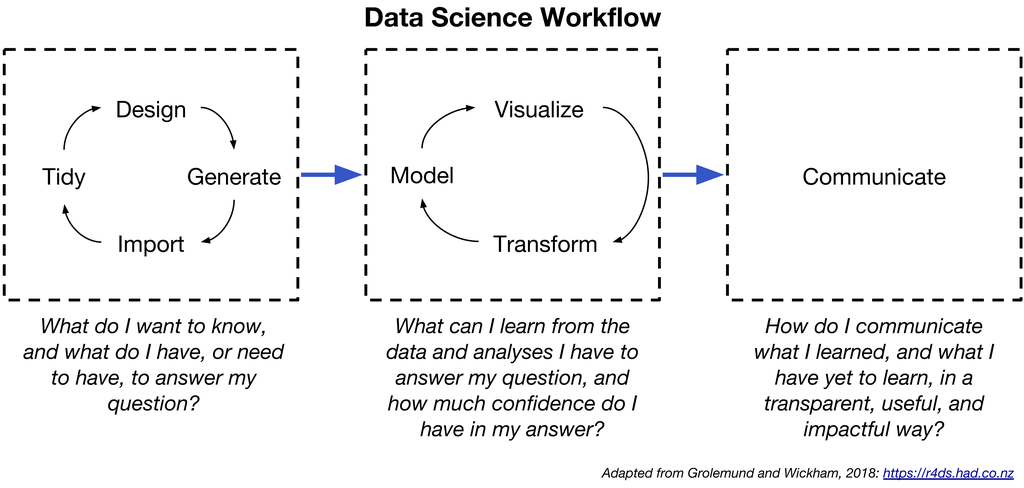

**“Knowledge is knowing a tomato is a fruit. Wisdom is not putting it in a fruit salad.”**

Miles Kington

**“Ensign, if I blow smoke up your ass, you just stay stupid.”**

BMCM “Noah”

Data science is easy. Good data science is really, really, really hard. Bad data science gets people killed.

**“Earlier today, a woman rang the BBC and said she heard there was a hurricane on the way. Well, if you’re watching, don’t worry, there isn’t!”**

Michael Fish (1987)

**Plan of the Day**

- Advance Work Review
- Session 3 Team Deliverable
- Causal Inference and Experiments
- Conditional Probabilities and Bayesian Inference
- Session 4 Team Deliverable
- Catch-up and Open Session

**Advance Work Review**

1  
11  
21  
1211  
111221

1  
11  
21  
1211  
111221  
312211

**“Things should be as simple as possible, but no simpler.”**

Albert Einstein

**Session 3 Team Deliverable**

**Casual Inference and Experiments**

$$x->y$$

There are three jointly necessary and sufficient conditions to establish a causal relationship between $x$ and $y$…

- Temporal sequencing: A change in $x$ had to happen before observing $y$.
- Non-spurious relationship: When I change $x$, $y$ *must* change in some way.
- There must be no other possible explanations (there isn’t another factor, $z$, influencing the $x$ —> $y$ relationship)

As we shift from thinking about associations to thinking about causal relationships—the hallmark of critical thinking—the challenge is dealing with all of the possible $z's$.

The more sex you have, the longer you live.

Oh, eating healthy helps too.

In your teams, brainstorm all of the (many) possible challenges that you see in drawing substantive conclusions about the relationship between longevity and sexual activity, and about longevity and diet.

The Italy study was what we call *observational*, because the researcher is not in control of the research setting or the potential causal variables.

It is really hard to establish a causal relationship in these settings, because of the difficulty in eliminating $z$’s.

The gold standard to maximize causal inference is the randomized controlled experiment.

In an experiment, we’re trying to isolate the causal effect of $x$ on $y$ by…

- Directly manipulating $x$
- Randomizing participants to the manipulated conditions
- Controlling the environment to eliminate other factors, $z's$, influencing the experiment

Businesses are [increasingly using sophisticated experiments](https://hbr.org/2017/09/the-surprising-power-of-online-experiments) in product research, management and human resources, operations, and many other settings.

Lets roll…

```r
library(tidyverse)
experiment.df <- read_csv("DSOM5509Experiment.csv")
```

Lets summarize the data a bit:

```r
experiment.df %>%
  count(EntManager, TaskSpecificity)
```

```
## # A tibble: 4 x 3
##   EntManager TaskSpecificity     n
##        <dbl>           <dbl> <int>
## 1          0               0   175
## 2          0               1   136
## 3          1               0   153
## 4          1               1   179
```

Our *multiple* regression model for today…

$$Creativity=\alpha+\beta{EntManager}+\beta{TaskSpecificity}+\epsilon$$

- *Creativity*: 1-7 ordinal scale indicating the *creativity* in completing a task
- *EntManager*: Categorical (dichotomous) variable with 1 indicating whether the participant had the Entrepreneurial Manager = YES condition
- *TaskSpecicity*: Categorical (dichotomous) variable with 1 indicating whether the participant had the Task Specificity = YES condition

In multiple regression, we’re usually interested in one (or some combination) of the following…

- Isolating the effect of $x$ on $y$ while controlling for possible $z$’s
- Estimating the effect of two (or more) meaningful $x$’s on $y$
- Determining which $x$ is most important
- Determining whether the effect of $x_1$ and $x_n$ are materially different from each other

Lets take a look at our model…

```r
creativity.model <- lm(Creativity ~ EntManager + TaskSpecificity,
                       data = experiment.df)
summary(creativity.model)
```

```
##
## Call:
## lm(formula = Creativity ~ EntManager + TaskSpecificity, data = experiment.df)
##
## Residuals:
##      Min       1Q   Median       3Q      Max
## -2.77909 -0.77909  0.02542  0.60430  3.02542
##
## Coefficients:
##                 Estimate Std. Error t value Pr(>|t|)
## (Intercept)      3.59119    0.06907  51.995  < 2e-16 ***
## EntManager       0.80452    0.08243   9.760  < 2e-16 ***
## TaskSpecificity  0.38339    0.08240   4.653 3.98e-06 ***
## ---
## Signif. codes:  0 '***' 0.001 '**' 0.01 '*' 0.05 '.' 0.1 ' ' 1
##
## Residual standard error: 1.039 on 640 degrees of freedom
## Multiple R-squared:  0.1661, Adjusted R-squared:  0.1635
## F-statistic: 63.74 on 2 and 640 DF,  p-value: < 2.2e-16
```

[output not shown]

Because both of our predictors are dichotomous, the coefficient estimate is the average expected difference in $y$ between the two values of $x$.

In our case, we would read the result of our analysis of the relationship between $EntManager$ and $Creativity$ as:

> We expect a .805 increase in creativity in the presence of an enterpreneurial manager, *holding constant* the effect of task specificity on creativity.

Ok, so how do we make sense visually of a multiple regression model?

Well, it’s a little on the tricky side, because we’ve “adjusted” each coefficient for the relationship between all of the other coefficients in the model.

Our predictors are also dichotomous, so there is no line of best fit; the coefficient estimate is simply a *shift* in the expected value of $y$.

```r
library(broom)
creativity.est.df <- tidy(creativity.model, conf.int = TRUE) %>%
  select(term, estimate, conf.low, conf.high) %>%
  filter(term != "(Intercept)")
creativity.est.df
```

```
## # A tibble: 2 x 4
##   term            estimate conf.low conf.high
##   <chr>              <dbl>    <dbl>     <dbl>
## 1 EntManager         0.805    0.643     0.966
## 2 TaskSpecificity    0.383    0.222     0.545
```

Now lets build the visualization…

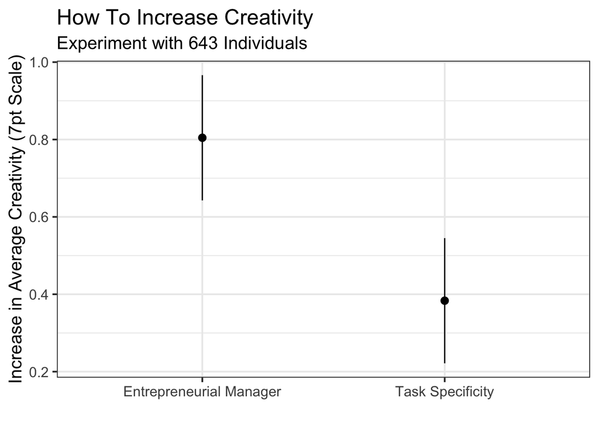

```r
ggplot(data = creativity.est.df, aes(y = estimate, x = term)) +
  geom_point() +
  geom_pointrange(aes(ymin = conf.low, ymax = conf.high)) +
  labs(title = "How To Increase Creativity",
       subtitle = "Experiment with 643 Individuals",
       y = "Increase in Average Creativity (7pt Scale)",
       x = "") +
  scale_x_discrete(breaks = c("EntManager", "TaskSpecificity"),
                   labels = c("Entrepreneurial Manager",
                              "Task Specificity")) +
  theme_bw(base_size = 15)
```

Take another look at the plot.

You should notice that the point estimate for Creativity is going up by about .8 for those respondents that had an Entrepreneurial Manager, and the point estimate for Creativity is going up by about .4 for those that had Task Specificity.

Another handy visualization for this type of data is a *box plot*. First up, some wrangling.

```r
boxplot.df <- experiment.df %>%
  mutate(EntManager = as.factor(EntManager),
         TaskSpecificity = as.factor(TaskSpecificity)) %>%
  mutate(EntManager = if_else(EntManager == "0",
                              "Conservative Manager",
                              "Entrepreneurial Manager")) %>%
  mutate(TaskSpecificity = if_else(TaskSpecificity == "0",
                                   "Few Directions",
                                   "Many Directions"))
```

Lets build a plot for the entrepreneurial manager manipulation.

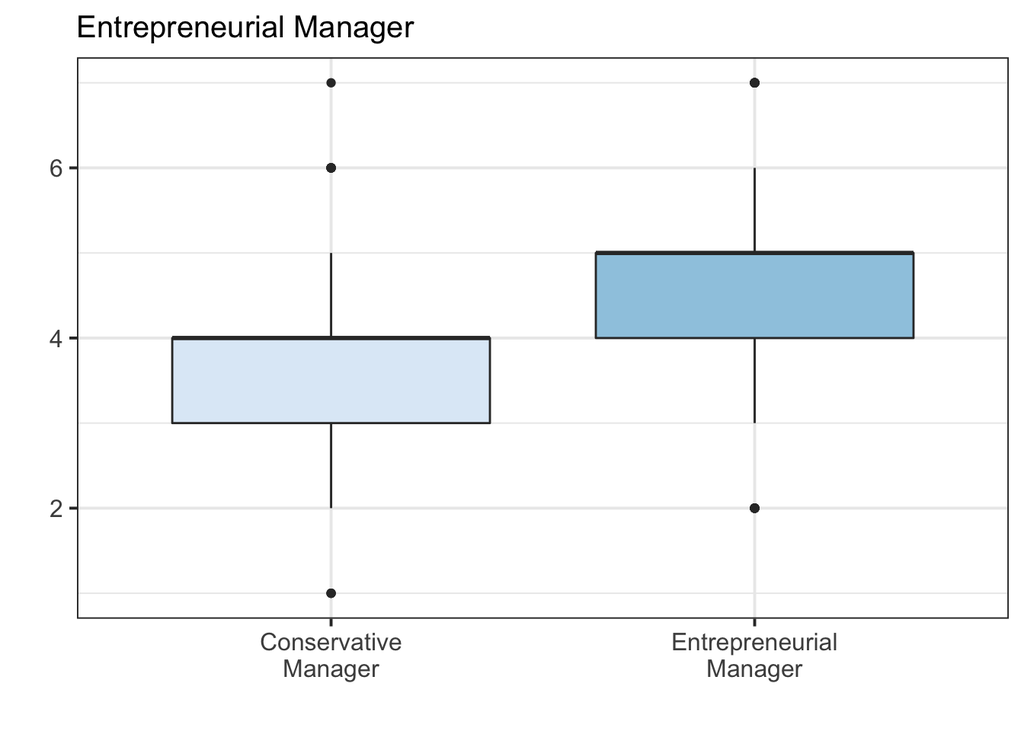

```r
ent.plot <- ggplot(data = boxplot.df %>%
                    mutate(EntManager = gsub(" ", "\n",
                                             EntManager)),
                   aes(y = Creativity, x = EntManager,
                       fill = EntManager)) +
  geom_boxplot() +
  scale_fill_brewer(palette = "Blues") +
  labs(subtitle = "Entrepreneurial Manager",
       y = "",
       x = "",
       fill = "") +
  guides(fill = FALSE) +
  theme_bw(base_size = 15)
ent.plot
```

Now the task specificity condition.

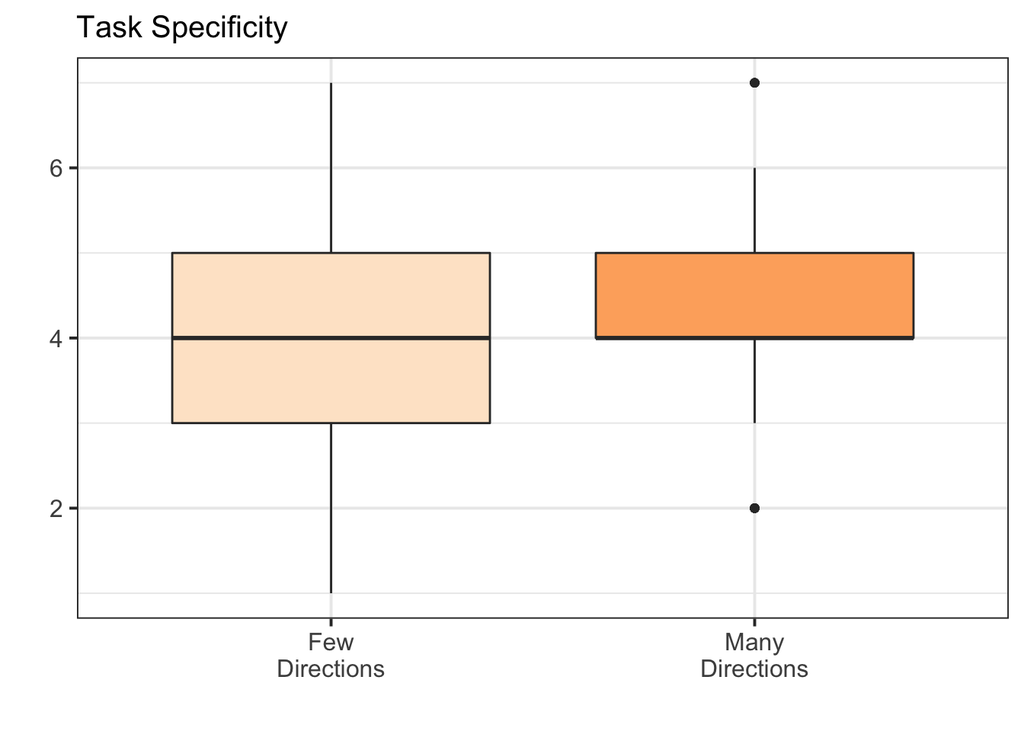

```r
ts.plot <- ggplot(data = boxplot.df %>%
                    mutate(TaskSpecificity = gsub(" ", "\n",
                                                  TaskSpecificity)),
                  aes(y = Creativity, x = TaskSpecificity,
                                         fill = TaskSpecificity)) +
  geom_boxplot() +
  scale_fill_brewer(palette = "Oranges") +
  labs(subtitle = "Task Specificity",
       y = "",
       x = "",
       fill = "") +
  guides(fill = FALSE) +
  theme_bw(base_size = 15)
ts.plot
```

Lets put these plots together.

```r
install.packages("gridExtra")
```

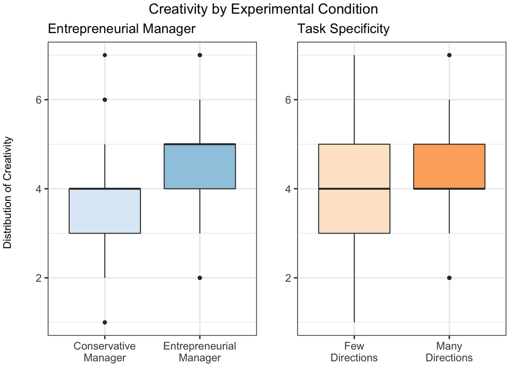

```r
library(gridExtra)
library(grid)
grid.arrange(ent.plot, ts.plot, ncol = 2,
             top = textGrob("Creativity by Experimental Condition",
                                gp = gpar(fontsize = 16)),
             left = "Distribution of Creativity")
```

**Conditional Probabilities and Bayesian Inference**

For some questions, it simply isn’t feasible—or ethical—to conduct an experiment.

In a perfect world, I would take roughly 2,000 octogenarians (a large sample) and randomly assign them to one of four conditions.

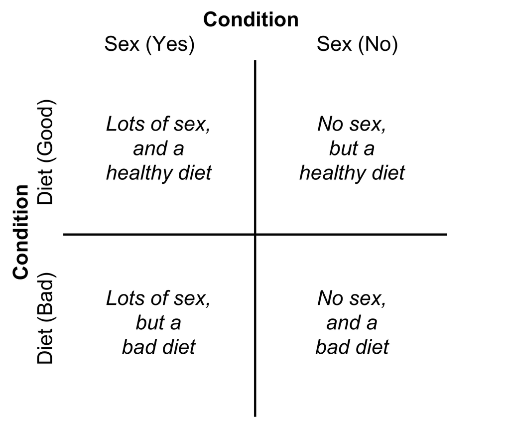

Then I’d record when they die, say over the next thirty years.

So I’m not likely to recruit enough 80 year-olds, the control group would likely be pretty upset, and I’m going to be retired thirty years from now.

Because an experiment is sometimes not feasible, we need to shift to thinking probabilistically, which means embracing uncertainty and variation.

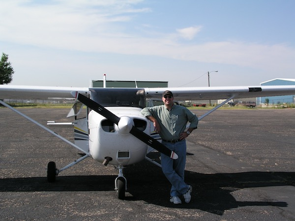

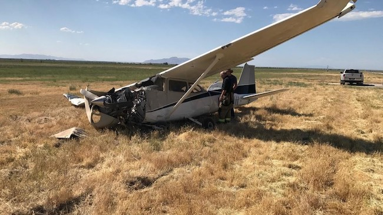

So just how dangerous is [flying (commercial)](https://catalog.data.gov/dataset/accidents-fatalities-and-rates-1995-through-2014-for-u-s-air-carriers-operating-under-14-c) anyway?

$$Pr(A) = \frac{\text{# of favorable outomes}}{\text{# of possible outcomes}}$$

For any given flight (measured by departures), what’s the probability of being in an accident?

$$Pr(Accident) = \frac{\text{Total Accidents}}{\text{Total Flights}}$$

According to our *USDOT* data, there is a 0.00032% probability of being in a accident for any given random flight.

So that’s a good thing.

What about being in a fatal accident?

$$Pr(\text{Fatal Accident}) = \frac{\text{Total Fatal Accidents}}{\text{Total Flights}}$$

0.000023%.

This probability is even lower, so that’s really good.

Ok, so the probability of being in an accident flying commercial is (fortunately) very small.

The probability of dying in a commercial airline accident is also (yeah!) very small.

The two independent probabilities really aren’t all that interesting.

The interesting question is this…If an accident occurs for a given random commercial airline flight, what is the probability of there being at least one fatality?

To answer this question, we need to move to a discussion of *conditional probability*.

$$Pr(A|B)$$

A = Event

`|` = “given that”

B = Condition

$$Pr(\text{Fatal accident } | \text{ That a commercial airline accident happened?})$$

7.3%.

Just a reminder, there was a 0.00032% chance of being in an accident, and a 0.000023% chance of being in a fatal accident.

So what’s so useful about understanding conditional probabilities? Well, think about it as a problem solving/deduction tool.

In a recent [Harvard Business Review article](https://hbr.org/2016/09/why-people-quit-their-jobs) about why people quit their jobs, there was an observation that job hunting spikes around people’s birthdays.

$$Pr(A|B)$$

$A$ = Probability of job hunting

$B$ = Probability of being my birthday

We read $Pr(A|B)$ as the probability of my job hunting given that it’s my birthday.

In the article, they give us a number (kind of) for this, and it’s a 12% increase over the baseline rate of job hunting (which we don’t have).

So what can we do with this information? Well, using a little bit of [Bayesian](https://en.wikipedia.org/wiki/Bayes%27_theorem) logic, we can ask a different conditional probability…

$$Pr(B|A)$$

What is the probability that it’s my birthday, given that I am job hunting?

$$Pr(A|B) = \frac{Pr(B|A)Pr(A)}{Pr(B)}$$

Bayes’ theorem works like any other algebraic equation. So long as we have at least three parameters, we can solve for the forth.

$$Pr(A|B) = \frac{Pr(B|A)Pr(A)}{Pr(B)}$$

$Pr(A)$…This is called our *prior*, and in this case it represents the baseline probability that a given individual is job hunting.

We get the prior from earlier research, logic, separate data analysis, intuition, experience, and so forth. For our purposes, lets say that the baseline probability that a person is job hunting is 10%.

$$Pr(A|B) = \frac{Pr(B|A)Pr(A)}{Pr(B)}$$

$Pr(A|B)$…The article actually gave us this data (yeah!), and it’s a 12% increase over the baseline rate. So, with our 10% baseline, the probability of job hunting when it’s your birthday is 11.2%.

$$Pr(A|B) = \frac{Pr(B|A)Pr(A)}{Pr(B)}$$

$Pr(B)$…This is the probability that any given day is the person’s birthday. Leaving aside leap year, on any given day there is a 0.27% chance (1 / 365) that the day is the person’s birthday.

Now lets put it together…

$$Pr(A|B) = \frac{Pr(B|A)Pr(A)}{Pr(B)}$$

$$0.000324/.10 = Pr(B|A)$$

The single most important thing to remember about conditional probabilities is this…

$$Pr(A|B) \ne Pr(B|A)$$

Go beyond birthdays and think about the probability that a person is job hunting if…

- She has a bad boss.
- He was just passed over for a promotion.
- She was contacted by an executive recruiter.

How would that information be valuable?

**Session 4 Team Deliverable**

*What is the probability that a woman has breast cancer, given that she had a mammogram indicate a positive?*

**Catch-up and open session**

What would you like to revisit?

**Next Session**

Friday, 8 March, 8:00AM—Constructing a narrative